# rrst_ch

# Identifying Outlier to exclude

```r
# Testing Outlier using boxplot (standard deviation)
df %>%
  group_by(group) %>%
  identify_outliers(rrst_sensitivity)
```

```
# A tibble: 1 × 166
  group pcode date         age sex   handedness   bmi   bdi stai_t stai_s   ias
  <fct> <dbl> <date>     <dbl> <fct>      <dbl> <dbl> <dbl>  <dbl>  <dbl> <dbl>
1 1        63 2024-05-08    38 1              1  19.5     9     34     28    87
# ℹ 155 more variables: maia_note <dbl>, maia_distr <dbl>, maia_worry <dbl>,
#   maia_attreg <dbl>, maia_aware <dbl>, maia_sfreg <dbl>, maia_body <dbl>,
#   maia_trust <dbl>, maia_total <dbl>, sdq <dbl>, contraception <fct>,
#   menopause <fct>, mc_phase <dbl>, sfmdrs <dbl>, seiz <dbl>, cgi <dbl>,
#   rrst_sensitivity <dbl>, ctq_emoab <dbl>, ctq_physab <dbl>, ctq_sexab <dbl>,
#   ctq_emoneg <dbl>, ctq_physneg <dbl>, ctq_minim <dbl>, ctq_total <dbl>,
#   traitPE_maiaRRST <dbl>, traitPE_iasRRST <dbl>, diagnosis <dbl>, …
```

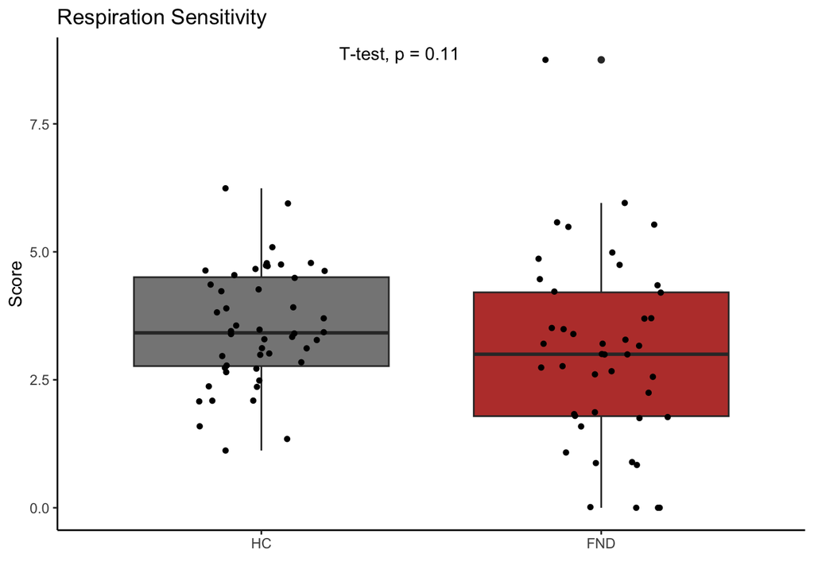

```r
# one outlier identified = P063 for rrst_sensitivity

#### Box-Plot with Jitter
plotBoxplotGroups <- function(df, var , tit ){
  plot <- ggplot(df, aes(x = group, y = var, fill = group)) +
    geom_boxplot(show.legend = TRUE) + # Show legend for boxplot
    labs(y = "Score") +
    theme_classic() +
    scale_fill_manual(values = c("#868686FF", "#BB4038")) +
    scale_x_discrete(labels = c("HC", "FND")) +
    guides(fill = "none") + # Remove the legend
    ggtitle(tit) +
    xlab("") +
    geom_jitter(shape = 16, position = position_jitter(0.2))

  return(plot)
}

p1 <- plotBoxplotGroups(df, (df$rrst_sensitivity), "Respiration Sensitivity") +
  stat_compare_means(method = "t.test", paired = FALSE, label.x = 1.3)
p1
```

```r
# Filter the rows where rrst_sensitivity is greater than 8 and display pcode (visually detected as extreme)
filtered_pcodes <- df[df$rrst_sensitivity > 8, "pcode"]
print(filtered_pcodes)
```

```
# A tibble: 1 × 1
  pcode
  <dbl>
1    63
```

```r
# P063

# Calculate mean and standard deviation of rrst_sensitivity
mean_rrst <- mean(df$rrst_sensitivity)
sd_rrst <- sd(df$rrst_sensitivity)
# Define the threshold for filtering (mean + 2.5 * SD)
threshold <- mean_rrst + 2.5 * sd_rrst # 7.07
# Filter the pcodes for rrst_sensitivity greater than the threshold
filtered_pcodes <- df[df$rrst_sensitivity > threshold, "pcode"]
# View the result
filtered_pcodes
```

```
# A tibble: 1 × 1
  pcode
  <dbl>
1    63
```

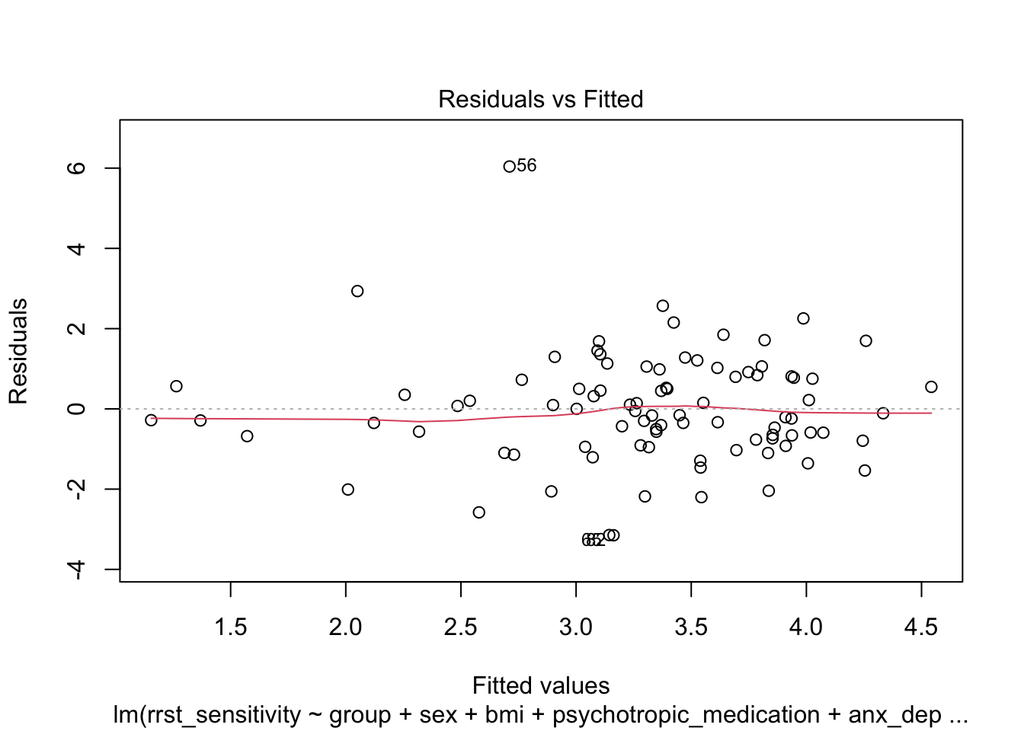

```r
# P063

# Testing the Assumptions in the main model (rrst sensitivity predicted by clinical variables)
# model:
lmrrst <- lm(
  rrst_sensitivity ~ group + sex + bmi + psychotropic_medication + anx_dep_SUM + ctq_total + sdq,
  data = df)
# testing assumptions
plot(lmrrst, which=1) # testing the assumptions of Linearity and Homoscedasticity with residuals vs fitted plot: the line should more or less be straight: observation 56 is a clear outlier
```

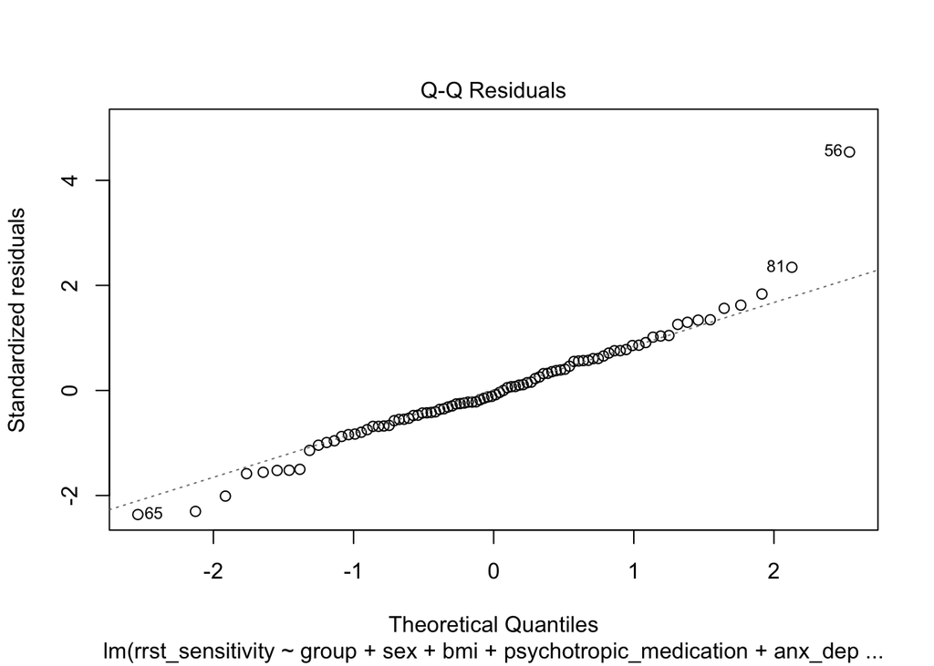

```r
plot(lmrrst, which=2) # testing the assumptions normality of residuals with  standardized quantiles: the data points should more or less on the line: observation 56 is a clear outlier (not as extreme but also noted: 81, 65)
```

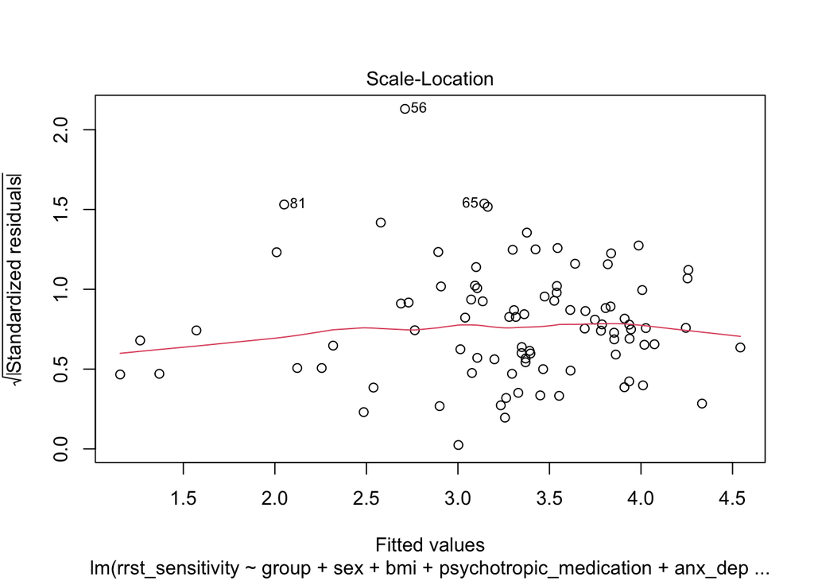

```r
plot(lmrrst, which=3) # testing the assumption of homoscedasticity with scale-location plot--> if there is an incline then we should consider log transformation: observation 56 is a clear outlier (not as extreme but also noted: 81, 65)
```

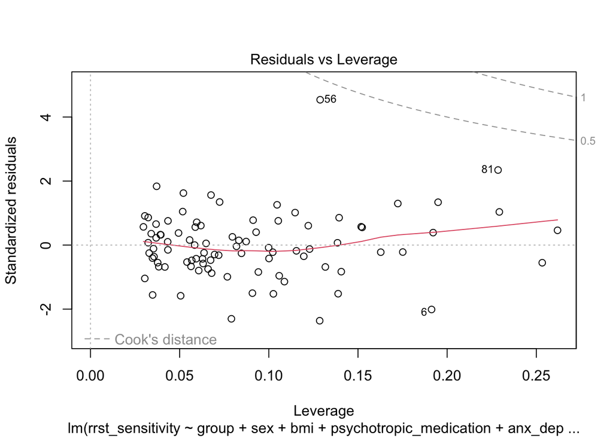

```r
plot(lmrrst, which=5) # testing leverage and influence = when an outlier has a lot of leverage over the regression line (high leverage & large residual; these points will lie close to the right top or bottom corners): observation 56 is a clear outlier (not as extreme but also noted: 81, 6)
```

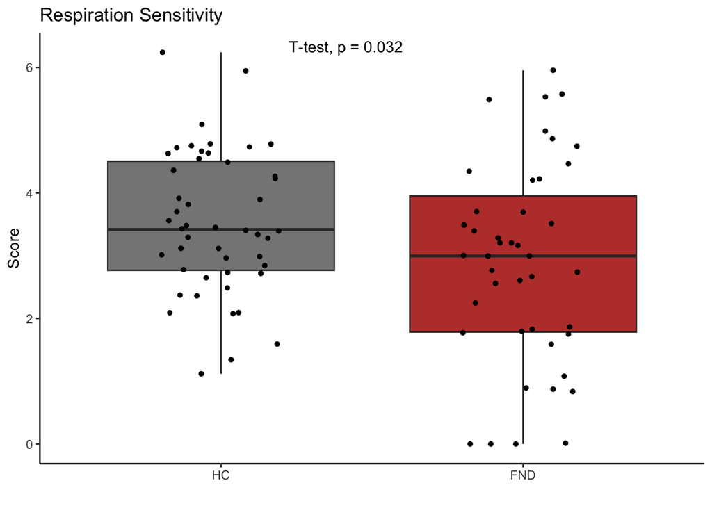

```r
# observation 56 (consistent outlier) = P063

df_exclusion <- df[df$pcode != "63", ]

p1b <- plotBoxplotGroups(df_exclusion, (df_exclusion$rrst_sensitivity), "Respiration Sensitivity") +
  stat_compare_means(method = "t.test", paired = FALSE, label.x = 1.3)
print(p1b)
```

```r
pdf("1.4.1b_RRST_box_exclusion_SIG.pdf")
p1b
dev.off()
```

```r
# Summary of Change - depending on Exclusion of Outlier
summary(df$rrst_sensitivity)  # no sig difference between group (cut of 0.05)
```

```
   Min. 1st Qu.  Median    Mean 3rd Qu.    Max.
  0.000   2.458   3.280   3.282   4.350   8.752
```

```r
summary(df_exclusion$rrst_sensitivity) # sig difference between group (cut of 0.05)
```

```
   Min. 1st Qu.  Median    Mean 3rd Qu.    Max.
  0.000   2.429   3.277   3.222   4.307   6.242
```

### Demographic Summary Table

```r
# overview across group and sex distribution
tbl <- df %>%
  mutate(sex = factor(sex, levels = c("1", "2"), labels = c("female", "male"))) %>%
  mutate(group = factor(group, levels = c("0", "1"), labels = c("HC", "FND")))
tbl1<-table(tbl$group,tbl$sex)
tbl1
```

```
      female male
  HC      35   13
  FND     32   12
```

```r
# overview for mean age across group
summary_stats <- tbl %>%
  group_by(group) %>%
  get_summary_stats(age, type = "full") # 'full' includes mean, SD, min, max, etc.
print(summary_stats)
```

```
# A tibble: 2 × 14
  group variable     n   min   max median    q1    q3   iqr   mad  mean    sd
  <fct> <fct>    <dbl> <dbl> <dbl>  <dbl> <dbl> <dbl> <dbl> <dbl> <dbl> <dbl>
1 HC    age         48    18    67   37    28    50    22    14.1  37.8  13.0
2 FND   age         44    18    64   38.5  31.8  46.5  14.8  11.1  38.5  11.7
# ℹ 2 more variables: se <dbl>, ci <dbl>
```

```r
res<-t.test(df$age[df$group == "0"], df$age[df$group == "1"]) #
res # no sig difference between the groups in age
```

```
    Welch Two Sample t-test

data:  df$age[df$group == "0"] and df$age[df$group == "1"]
t = -0.25816, df = 89.971, p-value = 0.7969
alternative hypothesis: true difference in means is not equal to 0
95 percent confidence interval:
 -5.780659  4.451114
sample estimates:
mean of x mean of y
 37.81250  38.47727
```

```r
# SUMMARY TABLE DEMOGRAPHICS -----
df_tbl <- df %>%
  mutate(sex = factor(sex, levels = c("1", "2"), labels = c("male", "female"))) %>%
  mutate(group = factor(group, levels = c("0", "1"), labels = c("HC", "FND"))) %>%
  mutate(psychotropic_medication = factor(psychotropic_medication, levels = c("0", "1"), labels = c("no", "yes")))

library(gtsummary)
library(dplyr)

# Select relevant columns from df_tbl
Data.t <- select(df_tbl, c("group", "sex", "age", "psychotropic_medication", "bmi", "bdi", "stai_s", "ctq_total", "sdq"))

# Create the summary table
tbl1 <- Data.t %>%
  tbl_summary(
    by = group,
    missing = "no",
    statistic = list(
      age = "{mean} ({sd})",
      sex = "{n} ({p})",
      psychotropic_medication ="{n} ({p})",
      bmi = "{mean} ({sd})",
      bdi = "{mean} ({sd})",
      stai_s = "{mean} ({sd})",
      ctq_total = "{mean} ({sd})",
      sdq = "{mean} ({sd})"
    ),
    digits = list(age = 1, sex = 1, psychotropic_medication = 1, contraception = 1, menopause = 1),
    label = list(age = "Age",
                 sex = "Sex",
                 psychotropic_medication= "Intake of psychotropic Medication (yes)",
                 bmi = "Body Mass Index (kg/m²)",
                 bdi = "Depression (BDI-II)",
                 stai_s = "State Anxiety (STAI-S)",
                 ctq_total = "Childhood Trauma (CTQ total)",
                 sdq = "Dissociation (SDQ-20)")
  ) %>%
  modify_header(list(label ~ "**Variable**")) %>%
  modify_caption("**Demographics Overview**") %>%
  modify_spanning_header(c("stat_1", "stat_2") ~ "**Group**") %>%
  add_p( test = list(
        age ~ "t.test",            # t-test for numeric variables (even though NOT normally distributed; rather use wilcox and then the median instead of the mean??)
        bmi ~ "t.test",            # t-test for bmi
        sex ~ "chisq.test",        # chi-square test for factor variables
        psychotropic_medication ~ "chisq.test",  # Fisher's exact test for small samples
        bdi ~ "t.test",
        stai_s ~ "t.test",
        ctq_total = "t.test",
        sdq="t.test"
      )) %>% #add p-value# add p-value (in case different variable should be tested differently, create a list and specify like that: add_p(test = list(age = "t.test", bmi = "wilcox.test"))
  add_overall(last = FALSE)

# Display the table
tbl1
```

**Demographics Overview**

[output not shown]

<sup>1</sup> n (%); Mean (SD)  
<sup>2</sup> Pearson’s Chi-squared test; Welch Two Sample t-test

### FND Summary Table

```r
# 1.4 SUMMARY TABLE for FND symptoms -----
# create variable of duation of months
df_FND <- df_FND %>%
  mutate(duration_months = interval(date_symptom_onset, date) %/% months(1)) # calculate month duration

as.numeric(df_FND$duration_months)
```

```
 [1]  32 168  39  26  43  41  25  28  25 305  72  15  12  37  36  71  69  63 173
[20]  59 207 139  71  52 259  34  39 113  34  60  22  20  41  58  31  29  39 161
[39]  89  74 124  11  69  29
```

```r
# Select only the defined variables
df_tbl <- df_FND %>%
  mutate(sex = factor(sex, levels = c("1", "2"), labels = c("female", "male")))

library(gtsummary)
library(dplyr)

# Select relevant columns from df_tbl
Data.t <- select(df_tbl, c("sex", "psychotropic_medication", "duration_months", "fds", "motor", "weakness", "sensory", "pppd", "cognitive"))

# Create the summary table
tbl <- Data.t %>%
  tbl_summary(
    by = sex,
    missing = "no",
    statistic = list(
      psychotropic_medication = "{n} ({p})",
      duration_months = "{mean} ({sd})",
      fds = "{n} ({p})",
      motor = "{n} ({p})",
      weakness = "{n} ({p})",
      sensory = "{n} ({p})",
      pppd = "{n} ({p})",
      cognitive = "{n} ({p})"
      ),
    digits = list(psychotropic_medication = 1,duration_months = 1,fds = 1,motor = 1,weakness = 1,sensory = 1,pppd = 1,cognitive = 1),
    label = list(
      sex = "Sex",
      psychotropic_medication = "Psychotropic Medication Intake [yes]",
      duration_months = "Symptom Duration [in months]",
      fds = "Functional Dissociative Seizures [yes]",
      motor = "motor + symptoms [yes]",
      weakness = "motor - symptoms [yes]",
      sensory = "sensory symptoms [yes]",
      pppd = "dizziness (PPPD) [yes]",
      cognitive = "cognitive symptoms [yes]"
    )
  ) %>%
  modify_header(list(label ~ "**Variable**")) %>%
  modify_caption("**Clinical Characteristics**") %>%
  modify_spanning_header(c("stat_1", "stat_2") ~ "**Group**") %>%
  add_overall(last = FALSE)

# Print the summary table
tbl
```

**Clinical Characteristics**

| **Variable** | **Overall**, N = 44<sup>1</sup> | **Group** **female**, N = 32<sup>1</sup> | **Group** **male**, N = 12<sup>1</sup> |
| --- | --- | --- | --- |
| Psychotropic Medication Intake [yes] |  |  |  |
| 0 | 24.0 (54.5) | 16.0 (50.0) | 8.0 (66.7) |
| 1 | 20.0 (45.5) | 16.0 (50.0) | 4.0 (33.3) |
| Symptom Duration [in months] | 71.5 (66.1) | 75.6 (71.1) | 60.3 (51.3) |
| Functional Dissociative Seizures [yes] | 8.0 (18.2) | 8.0 (25.0) | 0.0 (0.0) |
| motor + symptoms [yes] | 20.0 (45.5) | 13.0 (40.6) | 7.0 (58.3) |
| motor - symptoms [yes] | 30.0 (68.2) | 21.0 (65.6) | 9.0 (75.0) |
| sensory symptoms [yes] | 20.0 (45.5) | 16.0 (50.0) | 4.0 (33.3) |
| dizziness (PPPD) [yes] | 2.0 (4.5) | 2.0 (6.3) | 0.0 (0.0) |
| cognitive symptoms [yes] | 4.0 (9.1) | 4.0 (12.5) | 0.0 (0.0) |

<sup>1</sup> n (%); Mean (SD)

## 2) Group Differences - Baseline

Here we visualize the different distribution per group across all variables

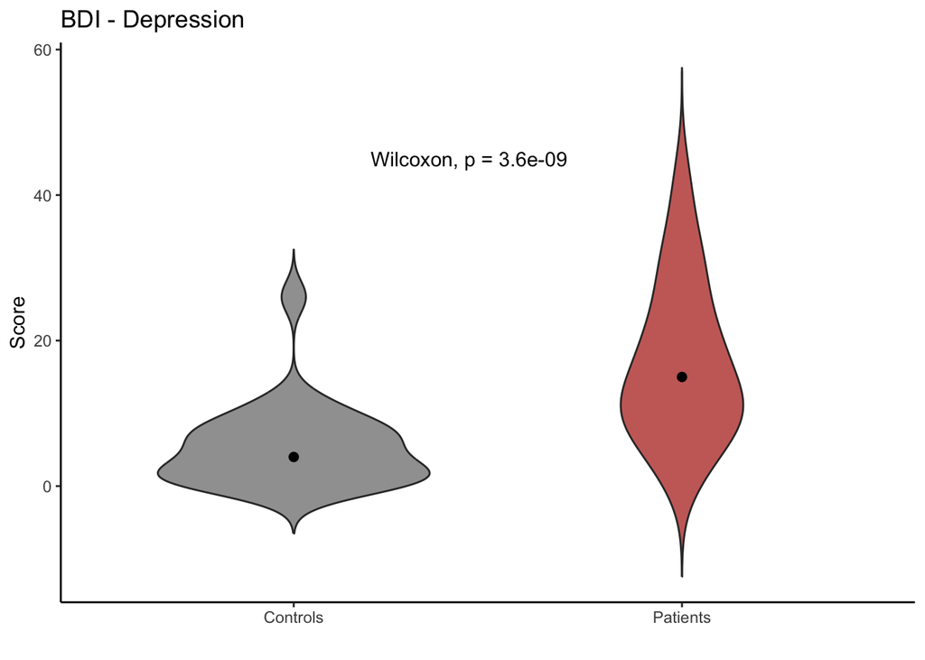

```r
df$group <- as.factor(df$group)

plotViolinGroups <- function(df, var , tit ){
  plot <-ggplot(df, aes(x=group, y=var, fill=group)) + # this is just the ground structure. We have group on x axis, our variable score on y, and we want to seperate the groups.
    geom_violin(show.legend = FALSE, width = 0.7, trim = FALSE, alpha = 0.8)+ # here we say what kind of plot we want to make; namely violin to show the distrubition of the original data (width to make it less wide and thus prettier)
    stat_summary(show.legend = FALSE, fun = median, geom = "point", color = "black", size = 2) +  # Add median point without legend
    labs(y = "Score") + # These are just the different titles
    theme_classic()+ # here we have the background, simple white :)
    scale_fill_manual(values = c("#868686FF", "#BB4038"))+ # google HEX codes and find your own colours.
    scale_x_discrete(labels=c("Controls", "Patients"))+  # these are our labels for the x axis
    guides(fill=guide_legend(title="Timepoint"))+ # and a title for our legend
    ggtitle(tit) +
    xlab("")

  return(plot)
}

p1 <- plotViolinGroups(df,df$bdi,"BDI - Depression")+ ggpubr::stat_compare_means(method = "wilcox.test", paired = FALSE, label.x = 1.3)
p1
```

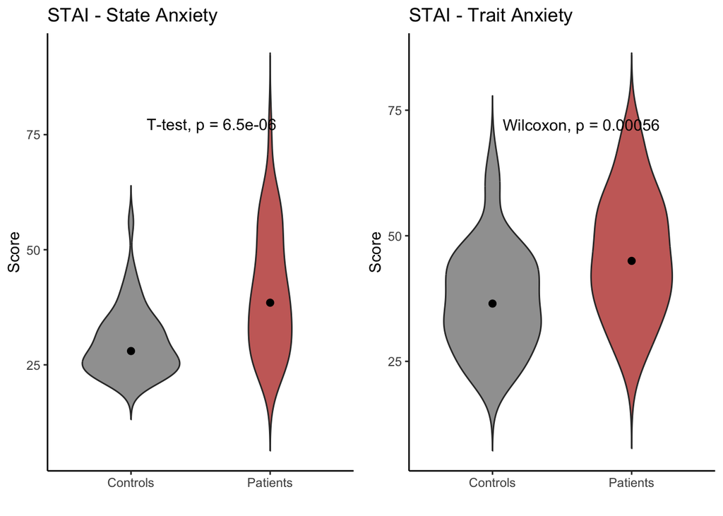

```r
p2 <- plotViolinGroups(df,df$stai_s,"STAI - State Anxiety")+ stat_compare_means(method = "t.test", paired = FALSE, label.x = 1.3)
p3 <- plotViolinGroups(df,df$stai_t,"STAI - Trait Anxiety")+ stat_compare_means(method = "wilcox.test", paired = FALSE, label.x = 1.3)
gridExtra::grid.arrange(p2, p3, ncol = 2)
```

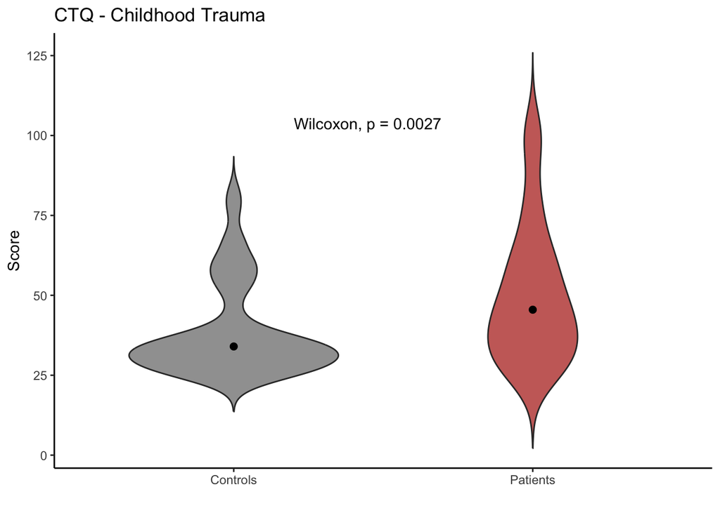

```r
p4 <- plotViolinGroups(df,df$ctq_total,"CTQ - Childhood Trauma")+ stat_compare_means(method = "wilcox.test", paired = FALSE, label.x = 1.3)
p4
```

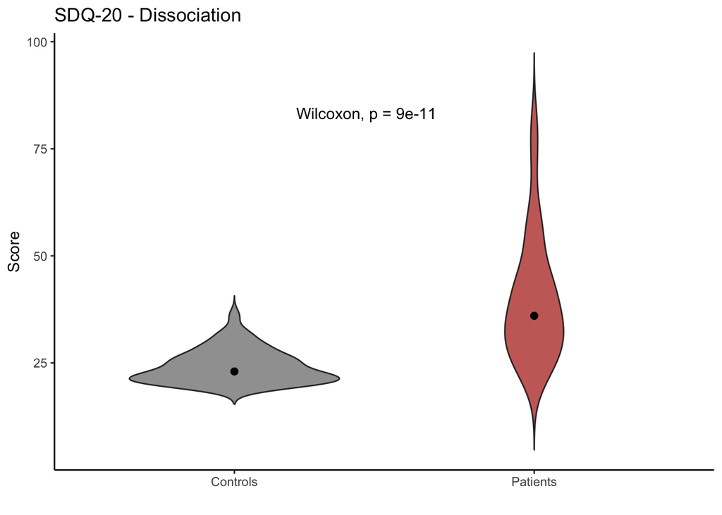

```r
p5 <- plotViolinGroups(df,df$sdq,"SDQ-20 - Dissociation")+ stat_compare_means(method = "wilcox.test", paired = FALSE, label.x = 1.3)
p5
```

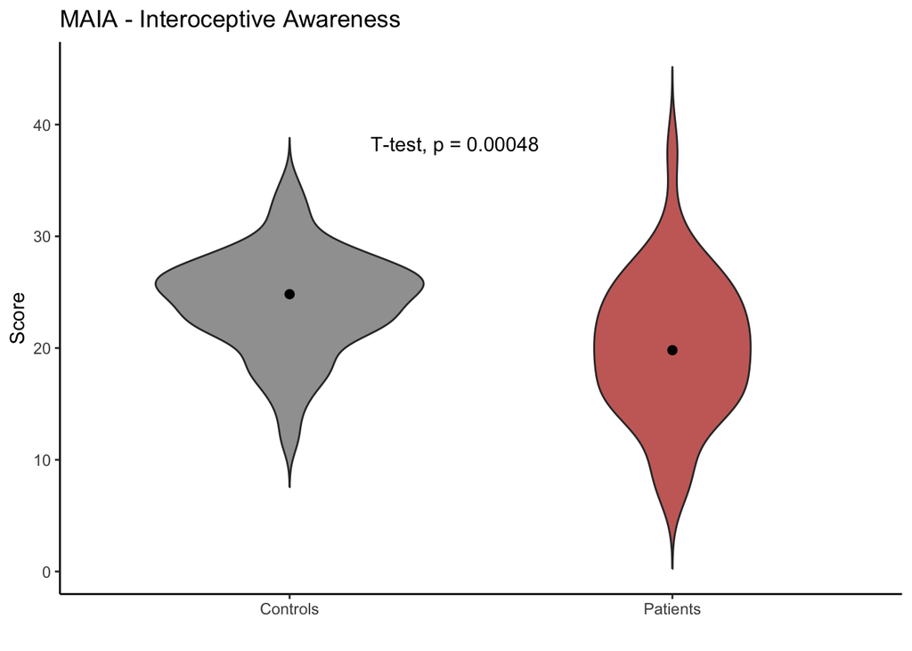

```r
p6 <- plotViolinGroups(df,df$maia_total,"MAIA - Interoceptive Awareness")+ stat_compare_means(method = "t.test", paired = FALSE, label.x = 1.3)
p6
```

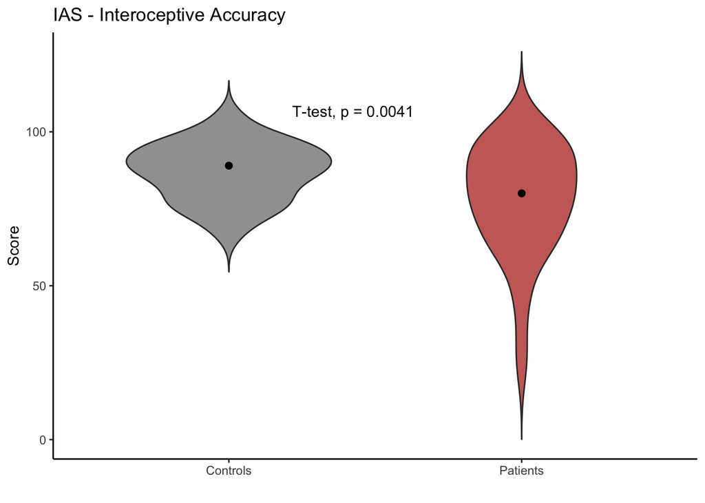

```r
p7 <- plotViolinGroups(df,df$ias,"IAS - Interoceptive Accuracy")+ stat_compare_means(method = "t.test", paired = FALSE, label.x = 1.3)
p7
```

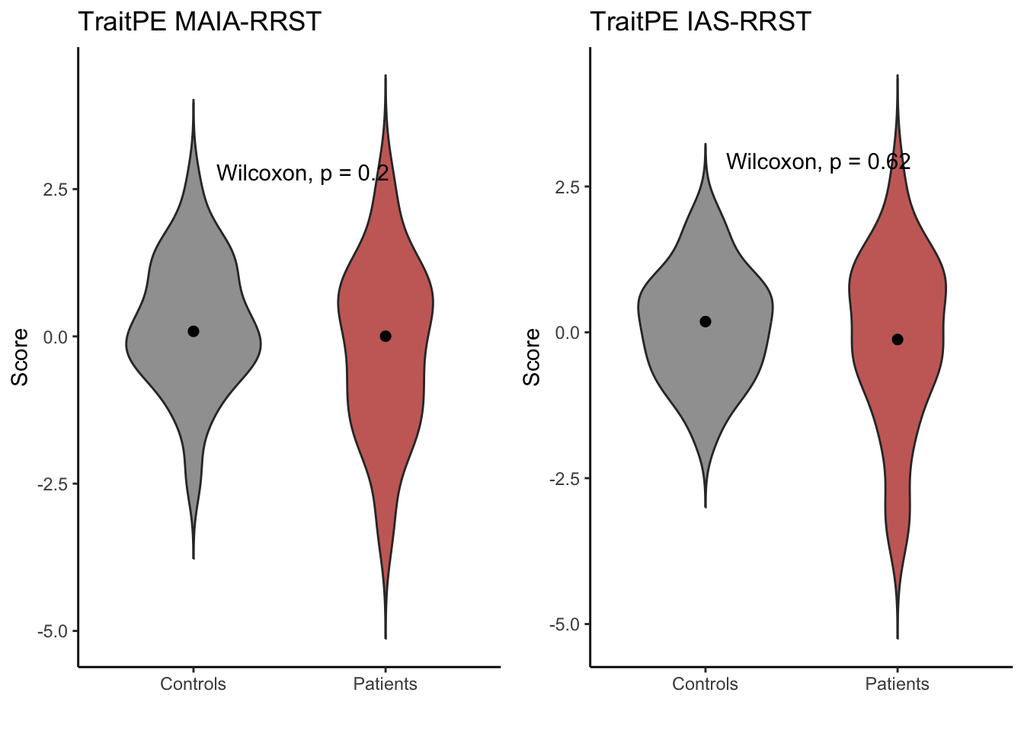

```r
p8 <- plotViolinGroups(df,df$traitPE_maiaRRST,"TraitPE MAIA-RRST")+ stat_compare_means(method = "wilcox.test", paired = FALSE, label.x = 1.3)
p9 <- plotViolinGroups(df,df$traitPE_iasRRST,"TraitPE IAS-RRST")+ stat_compare_means(method = "wilcox.test", paired = FALSE, label.x = 1.3)
gridExtra::grid.arrange(p8, p9, ncol = 2)
```

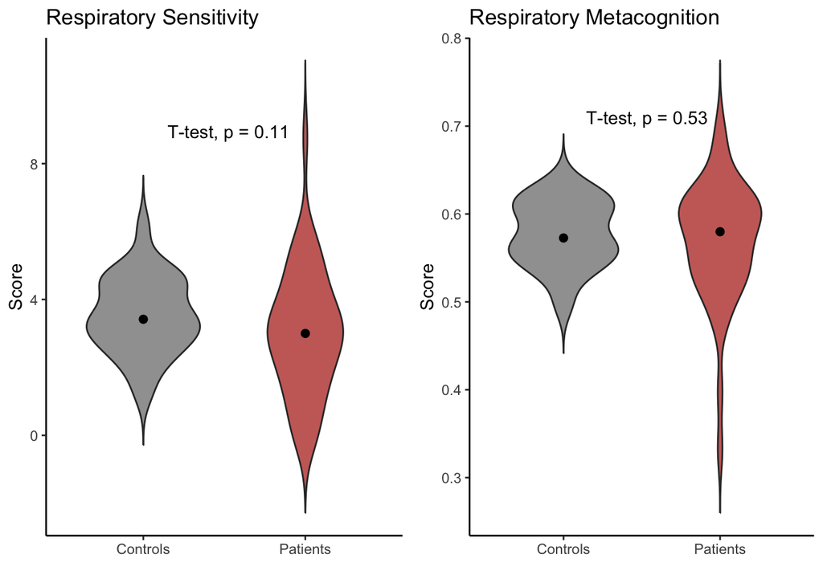

```r
p10 <- plotViolinGroups(df,df$rrst_sensitivity,"Respiratory Sensitivity")+ stat_compare_means(method = "t.test", paired = FALSE, label.x = 1.3)
p11 <- plotViolinGroups(df,df$metascore,"Respiratory Metacognition")+ stat_compare_means(method = "t.test", paired = FALSE, label.x = 1.3)
gridExtra::grid.arrange(p10, p11, ncol = 2)
```

## 3) Interoception

Here we model interoceptive variables using group and clinical predictors

```r
# predicting group with interoceptive variables and most important covariates
glm <- glm(formula = group ~  sex + rrst_sensitivity  + metascore + maia_total + ias + anx_dep_SUM + ctq_total + sdq,
            data = df,
            family = binomial) # as group has two levels
summary(glm) # SDQ predict group
```

```
Call:
glm(formula = group ~ sex + rrst_sensitivity + metascore + maia_total +
    ias + anx_dep_SUM + ctq_total + sdq, family = binomial, data = df)

Coefficients:
                  Estimate Std. Error z value Pr(>|z|)
(Intercept)      -11.12435    4.95888  -2.243 0.024876 *
sex2               0.73767    0.72893   1.012 0.311548
rrst_sensitivity   0.10094    0.21449   0.471 0.637911
metascore          8.88342    6.26152   1.419 0.155977
maia_total        -0.06245    0.07507  -0.832 0.405440
ias               -0.02090    0.02234  -0.936 0.349491
anx_dep_SUM        0.02104    0.02266   0.929 0.353050
ctq_total          0.01403    0.02062   0.680 0.496370
sdq                0.23437    0.06915   3.389 0.000701 ***
---
Signif. codes:  0 '***' 0.001 '**' 0.01 '*' 0.05 '.' 0.1 ' ' 1

(Dispersion parameter for binomial family taken to be 1)

    Null deviance: 127.365  on 91  degrees of freedom
Residual deviance:  66.125  on 83  degrees of freedom
AIC: 84.125

Number of Fisher Scoring iterations: 6
```

```r
# predciting rrst sensitvity with covariates
lm<-lm(rrst_sensitivity ~ group + sex + bmi + psychotropic_medication + anx_dep_SUM + ctq_total + sdq,
  data = df)
summary(lm) #  # SDQ sig associated with rrst sensitvity
```

```
Call:
lm(formula = rrst_sensitivity ~ group + sex + bmi + psychotropic_medication +
    anx_dep_SUM + ctq_total + sdq, data = df)

Residuals:
    Min      1Q  Median      3Q     Max
-3.1496 -0.7588 -0.1332  0.7928  6.0406

Coefficients:
                          Estimate Std. Error t value Pr(>|t|)
(Intercept)               4.977450   1.058444   4.703 1.03e-05 ***
group1                    0.219735   0.406135   0.541  0.58995
sex2                      0.696655   0.358261   1.945  0.05526 .
bmi                      -0.051693   0.041142  -1.256  0.21252
psychotropic_medication1 -0.582941   0.448171  -1.301  0.19700
anx_dep_SUM               0.006736   0.009458   0.712  0.47839
ctq_total                 0.013883   0.009263   1.499  0.13778
sdq                      -0.048320   0.016192  -2.984  0.00374 **
---
Signif. codes:  0 '***' 0.001 '**' 0.01 '*' 0.05 '.' 0.1 ' ' 1

Residual standard error: 1.426 on 82 degrees of freedom
  (2 observations deleted due to missingness)
Multiple R-squared:  0.1969,    Adjusted R-squared:  0.1283
F-statistic: 2.872 on 7 and 82 DF,  p-value: 0.009853
```

```r
# predciting  rrst metascore with covariates
lm<-lm(metascore ~ group + sex + bmi + psychotropic_medication + anx_dep_SUM + ctq_total + sdq,
  data = df)
summary(lm) #  # SDQ and CTQ sig associated with metascore
```

```
Call:
lm(formula = metascore ~ group + sex + bmi + psychotropic_medication +
    anx_dep_SUM + ctq_total + sdq, data = df)

Residuals:
      Min        1Q    Median        3Q       Max
-0.192614 -0.028603  0.001909  0.034596  0.102219

Coefficients:
                           Estimate Std. Error t value Pr(>|t|)
(Intercept)               0.6315038  0.0384701  16.415   <2e-16 ***
group1                    0.0217289  0.0147613   1.472   0.1448
sex2                     -0.0061720  0.0130213  -0.474   0.6368
bmi                      -0.0018907  0.0014953  -1.264   0.2097
psychotropic_medication1 -0.0242442  0.0162891  -1.488   0.1405
anx_dep_SUM               0.0001438  0.0003438   0.418   0.6768
ctq_total                 0.0007237  0.0003367   2.150   0.0345 *
sdq                      -0.0017237  0.0005885  -2.929   0.0044 **
---
Signif. codes:  0 '***' 0.001 '**' 0.01 '*' 0.05 '.' 0.1 ' ' 1

Residual standard error: 0.05182 on 82 degrees of freedom
  (2 observations deleted due to missingness)
Multiple R-squared:  0.1745,    Adjusted R-squared:  0.1041
F-statistic: 2.477 on 7 and 82 DF,  p-value: 0.02338
```

```r
# predciting  traitPE uing RRST and MAIA with covariates
lm<-lm(traitPE_maiaRRST ~ group + sex + bmi + psychotropic_medication + anx_dep_SUM + ctq_total + sdq,
  data = df)
summary(lm) #  ANX-DEP sum score sig assocaited with traitPE using RRST and MAIA
```

```
Call:
lm(formula = traitPE_maiaRRST ~ group + sex + bmi + psychotropic_medication +
    anx_dep_SUM + ctq_total + sdq, data = df)

Residuals:
    Min      1Q  Median      3Q     Max
-3.6648 -0.7589  0.0079  0.8468  2.7218

Coefficients:
                          Estimate Std. Error t value Pr(>|t|)
(Intercept)              -0.399532   0.876365  -0.456 0.649669
group1                   -0.462840   0.336269  -1.376 0.172445
sex2                     -0.530121   0.296631  -1.787 0.077610 .
bmi                       0.050944   0.034065   1.496 0.138618
psychotropic_medication1  0.713071   0.371074   1.922 0.058125 .
anx_dep_SUM              -0.027481   0.007831  -3.509 0.000733 ***
ctq_total                 0.004160   0.007670   0.542 0.589020
sdq                       0.018057   0.013406   1.347 0.181734
---
Signif. codes:  0 '***' 0.001 '**' 0.01 '*' 0.05 '.' 0.1 ' ' 1

Residual standard error: 1.18 on 82 degrees of freedom
  (2 observations deleted due to missingness)
Multiple R-squared:  0.1828,    Adjusted R-squared:  0.113
F-statistic:  2.62 on 7 and 82 DF,  p-value: 0.0171
```

```r
# predciting  traitPE uing RRST and MAIA with covariates
lm<-lm(traitPE_iasRRST ~ group + sex + bmi + psychotropic_medication + anx_dep_SUM + ctq_total + sdq,
  data = df)
summary(lm) #  no sig assocaition with traitPE usign RRST and IAS
```

```
Call:
lm(formula = traitPE_iasRRST ~ group + sex + bmi + psychotropic_medication +
    anx_dep_SUM + ctq_total + sdq, data = df)

Residuals:
    Min      1Q  Median      3Q     Max
-3.5722 -0.6886  0.1853  0.7085  2.6444

Coefficients:
                          Estimate Std. Error t value Pr(>|t|)
(Intercept)               0.387904   0.920506   0.421    0.675
group1                   -0.271559   0.353206  -0.769    0.444
sex2                     -0.335077   0.311572  -1.075    0.285
bmi                      -0.004516   0.035780  -0.126    0.900
psychotropic_medication1  0.500769   0.389764   1.285    0.202
anx_dep_SUM              -0.001564   0.008226  -0.190    0.850
ctq_total                 0.003162   0.008056   0.393    0.696
sdq                      -0.008585   0.014082  -0.610    0.544

Residual standard error: 1.24 on 82 degrees of freedom
  (2 observations deleted due to missingness)
Multiple R-squared:  0.05176,   Adjusted R-squared:  -0.02919
F-statistic: 0.6394 on 7 and 82 DF,  p-value: 0.722
```

## 4) Symptom Severity

Here we model symptom severity (SFMDRS/CGI/SDQ) using interoceptive predictors

```r
# for FND group only
# Compute the correlation matrix with variables of symptom severity to see whether they correlate
# Select the desired variables
severity_variables <- df_FND[, c("sfmdrs", "cgi", "sdq", "sum_positive_signs", "sum_severity")]

# Compute the correlation matrix with rcorr
correlation_results <- rcorr(as.matrix(severity_variables))

# Extract correlation coefficients
cor_matrix <- correlation_results$r

# Extract p-values
p_matrix <- correlation_results$P

# Print results
cor_matrix
```

```
                       sfmdrs       cgi        sdq sum_positive_signs
sfmdrs             1.00000000 0.5770168 0.05422324          0.1626448
cgi                0.57701682 1.0000000 0.28537094          0.5743582
sdq                0.05422324 0.2853709 1.00000000          0.4810280
sum_positive_signs 0.16264478 0.5743582 0.48102796          1.0000000
sum_severity       0.17042753 0.3535830 0.06628783          0.1503324
                   sum_severity
sfmdrs               0.17042753
cgi                  0.35358298
sdq                  0.06628783
sum_positive_signs   0.15033241
sum_severity         1.00000000
```

```r
p_matrix
```

```
                         sfmdrs          cgi          sdq sum_positive_signs
sfmdrs                       NA 0.0000412958 0.7266545570       0.2914946472
cgi                0.0000412958           NA 0.0604226398       0.0000456498
sdq                0.7266545570 0.0604226398           NA       0.0009486588
sum_positive_signs 0.2914946472 0.0000456498 0.0009486588                 NA
sum_severity       0.2687008572 0.0185474349 0.6690034491       0.3300391323
                   sum_severity
sfmdrs               0.26870086
cgi                  0.01854743
sdq                  0.66900345
sum_positive_signs   0.33003913
sum_severity                 NA
```

```r
# SIG correlations of different symptom severity scores
### CGI & SFMDRS corr: r=0.5770168, p=0.0000412958
### CGI & SUM_POS corr: r=0.5743582, p=0.0000456498
### SDQ & SUM_POS corr: r=0.4810280, p=0.0009486588
### CGI & SUM_SEVERITY corr: r=0.35358298, p=0.01854743

# modeling the symptom severity of FND patients by adding the interoceptive variables as predictors
#SFMDRS
sfmdrslm <- lm(formula = sfmdrs ~  rrst_sensitivity + metascore + ias + maia_total,
               data = df_FND)
summary(sfmdrslm)
```

```
Call:
lm(formula = sfmdrs ~ rrst_sensitivity + metascore + ias + maia_total,
    data = df_FND)

Residuals:
    Min      1Q  Median      3Q     Max
-9.4930 -4.3974 -0.8133  2.8709 17.5741

Coefficients:
                   Estimate Std. Error t value Pr(>|t|)
(Intercept)       12.605092   8.146858   1.547    0.130
rrst_sensitivity   0.169769   0.549585   0.309    0.759
metascore        -19.902123  15.810223  -1.259    0.216
ias                0.002214   0.056534   0.039    0.969
maia_total         0.217452   0.169050   1.286    0.206

Residual standard error: 6.175 on 39 degrees of freedom
Multiple R-squared:  0.06069,   Adjusted R-squared:  -0.03565
F-statistic:  0.63 on 4 and 39 DF,  p-value: 0.6441
```

```r
#CGI
cgilm <- lm(formula = cgi ~   rrst_sensitivity + metascore + ias + maia_total,
            data = df_FND)
summary(cgilm)
```

```
Call:
lm(formula = cgi ~ rrst_sensitivity + metascore + ias + maia_total,
    data = df_FND)

Residuals:
     Min       1Q   Median       3Q      Max
-2.38544 -1.20222 -0.09836  0.91907  2.81192

Coefficients:
                 Estimate Std. Error t value Pr(>|t|)
(Intercept)       5.18811    1.97542   2.626   0.0123 *
rrst_sensitivity  0.03240    0.13326   0.243   0.8092
metascore        -4.15185    3.83361  -1.083   0.2855
ias              -0.02276    0.01371  -1.660   0.1049
maia_total        0.07215    0.04099   1.760   0.0862 .
---
Signif. codes:  0 '***' 0.001 '**' 0.01 '*' 0.05 '.' 0.1 ' ' 1

Residual standard error: 1.497 on 39 degrees of freedom
Multiple R-squared:  0.1312,    Adjusted R-squared:  0.0421
F-statistic: 1.472 on 4 and 39 DF,  p-value: 0.2292
```

```r
#Sum score pos signs  (pos signs like wekaness in deltoid/stenocleido etc, co-contractions, give way weakness, hoover, hyposensitivity)
sum_pos_lm <- lm(formula = sum_positive_signs ~  rrst_sensitivity + metascore + ias + maia_total,
               data = df_FND)
summary(sum_pos_lm)   # weak evidence for association with rrst_sensitivity p=0.0504
```

```
Call:
lm(formula = sum_positive_signs ~ rrst_sensitivity + metascore +
    ias + maia_total, data = df_FND)

Residuals:
    Min      1Q  Median      3Q     Max
-16.850  -3.760   0.447   3.166  25.804

Coefficients:
                 Estimate Std. Error t value Pr(>|t|)
(Intercept)      11.62783    9.83850   1.182   0.2444
rrst_sensitivity -1.34006    0.66370  -2.019   0.0504 .
metascore        11.18159   19.09312   0.586   0.5615
ias              -0.04101    0.06827  -0.601   0.5515
maia_total        0.31918    0.20415   1.563   0.1260
---
Signif. codes:  0 '***' 0.001 '**' 0.01 '*' 0.05 '.' 0.1 ' ' 1

Residual standard error: 7.457 on 39 degrees of freedom
Multiple R-squared:  0.1466,    Adjusted R-squared:  0.05902
F-statistic: 1.674 on 4 and 39 DF,  p-value: 0.1755
```

```r
#Sum score severity (motor weakness and seizure frequency)
sum_pos_lm <- lm(formula = sum_severity ~  rrst_sensitivity + metascore + ias + maia_total,
               data = df_FND)
summary(sum_pos_lm)  # weak evidence for association with metascore p= 0.069
```

```
Call:
lm(formula = sum_severity ~ rrst_sensitivity + metascore + ias +
    maia_total, data = df_FND)

Residuals:
    Min      1Q  Median      3Q     Max
-51.991 -15.423  -6.687   5.138 245.131

Coefficients:
                   Estimate Std. Error t value Pr(>|t|)
(Intercept)       100.04567   56.41708   1.773    0.084 .
rrst_sensitivity   -1.00129    3.80588  -0.263    0.794
metascore        -204.71158  109.48596  -1.870    0.069 .
ias                 0.08706    0.39150   0.222    0.825
maia_total          1.42279    1.17067   1.215    0.232
---
Signif. codes:  0 '***' 0.001 '**' 0.01 '*' 0.05 '.' 0.1 ' ' 1

Residual standard error: 42.76 on 39 degrees of freedom
Multiple R-squared:  0.09923,   Adjusted R-squared:  0.006848
F-statistic: 1.074 on 4 and 39 DF,  p-value: 0.3824
```

```r
#SDQ
sdqlm <- lm(formula = sdq ~ rrst_sensitivity + metascore + ias + maia_total,
            data = df_FND)
summary(sdqlm)
```

```
Call:
lm(formula = sdq ~ rrst_sensitivity + metascore + ias + maia_total,
    data = df_FND)

Residuals:
    Min      1Q  Median      3Q     Max
-25.161  -6.008  -1.486   5.907  41.188

Coefficients:
                  Estimate Std. Error t value Pr(>|t|)
(Intercept)       84.38943   17.43796   4.839 2.08e-05 ***
rrst_sensitivity  -2.06181    1.17636  -1.753   0.0875 .
metascore        -46.59118   33.84102  -1.377   0.1764
ias               -0.17761    0.12101  -1.468   0.1502
maia_total         0.08984    0.36184   0.248   0.8052
---
Signif. codes:  0 '***' 0.001 '**' 0.01 '*' 0.05 '.' 0.1 ' ' 1

Residual standard error: 13.22 on 39 degrees of freedom
Multiple R-squared:  0.2455,    Adjusted R-squared:  0.1682
F-statistic: 3.173 on 4 and 39 DF,  p-value: 0.02379
```

```r
#SDQ using FULL POPULATION (as we also have sdq scores for HC)
lm <- lm(formula = sdq ~ group + rrst_sensitivity + metascore + ias + maia_total,
            data = df)
summary(lm) # SDQ sig assocaited with group, RRST sensitivity, and IAS
```

```
Call:
lm(formula = sdq ~ group + rrst_sensitivity + metascore + ias +
    maia_total, data = df)

Residuals:
    Min      1Q  Median      3Q     Max
-22.947  -3.851  -0.685   3.087  41.520

Coefficients:
                  Estimate Std. Error t value Pr(>|t|)
(Intercept)       65.10993   11.29752   5.763 1.26e-07 ***
group1            12.58753    2.18074   5.772 1.21e-07 ***
rrst_sensitivity  -1.54687    0.68806  -2.248   0.0271 *
metascore        -32.79388   19.58991  -1.674   0.0978 .
ias               -0.17178    0.07652  -2.245   0.0273 *
maia_total        -0.06906    0.20209  -0.342   0.7334
---
Signif. codes:  0 '***' 0.001 '**' 0.01 '*' 0.05 '.' 0.1 ' ' 1

Residual standard error: 9.501 on 86 degrees of freedom
Multiple R-squared:  0.4903,    Adjusted R-squared:  0.4606
F-statistic: 16.54 on 5 and 86 DF,  p-value: 2.05e-11
```

## 5) Interoception per Group

Here we model interoceptive variables using clinical predictors, separatly per group

```r
# modeling the variance of interoceptive performance by including the common/typical co-variates
# here including SEX and AGE as we dont control for it anymore in the design (HC vs FND)
# RRST sensitivity FND
lmrrst <- lm(
  rrst_sensitivity ~ sex + age + bmi + anx_dep_SUM + ctq_total + sdq,
  data = df_FND)
summary(lmrrst) # SDQ
```

```
Call:
lm(formula = rrst_sensitivity ~ sex + age + bmi + anx_dep_SUM +
    ctq_total + sdq, data = df_FND)

Residuals:
    Min      1Q  Median      3Q     Max
-3.6159 -0.6904 -0.2007  0.8324  5.2827

Coefficients:
             Estimate Std. Error t value Pr(>|t|)
(Intercept)  7.560676   1.914192   3.950 0.000338 ***
sex2         0.810261   0.620888   1.305 0.199950
age         -0.016381   0.024699  -0.663 0.511302
bmi         -0.098766   0.058490  -1.689 0.099712 .
anx_dep_SUM -0.009233   0.013765  -0.671 0.506528
ctq_total    0.021019   0.013766   1.527 0.135288
sdq         -0.052922   0.021107  -2.507 0.016682 *
---
Signif. codes:  0 '***' 0.001 '**' 0.01 '*' 0.05 '.' 0.1 ' ' 1

Residual standard error: 1.695 on 37 degrees of freedom
Multiple R-squared:  0.2607,    Adjusted R-squared:  0.1408
F-statistic: 2.174 on 6 and 37 DF,  p-value: 0.06772
```

```r
# RRST sensitivity HC
lmrrst <- lm(
  rrst_sensitivity ~ sex + age + bmi + anx_dep_SUM + ctq_total + sdq,
  data = df_HC)
summary(lmrrst) # BMI and ANX-DEP
```

```
Call:
lm(formula = rrst_sensitivity ~ sex + age + bmi + anx_dep_SUM +
    ctq_total + sdq, data = df_HC)

Residuals:
     Min       1Q   Median       3Q      Max
-2.37183 -0.66239 -0.08816  0.71987  2.16384

Coefficients:
            Estimate Std. Error t value Pr(>|t|)
(Intercept)  2.70382    1.51938   1.780   0.0826 .
sex2         0.66620    0.36666   1.817   0.0765 .
age         -0.02504    0.01299  -1.927   0.0609 .
bmi          0.12298    0.05641   2.180   0.0350 *
anx_dep_SUM  0.02850    0.01293   2.204   0.0332 *
ctq_total   -0.00667    0.01155  -0.577   0.5668
sdq         -0.09298    0.04691  -1.982   0.0542 .
---
Signif. codes:  0 '***' 0.001 '**' 0.01 '*' 0.05 '.' 0.1 ' ' 1

Residual standard error: 1.037 on 41 degrees of freedom
Multiple R-squared:  0.2634,    Adjusted R-squared:  0.1556
F-statistic: 2.444 on 6 and 41 DF,  p-value: 0.04115
```

```r
# RRST metascore FND
lmmeta <- lm(
  metascore ~ sex + age + bmi + anx_dep_SUM + ctq_total + sdq,
  data = df_FND)
summary(lmmeta) # SDQ and AGE
```

```
Call:
lm(formula = metascore ~ sex + age + bmi + anx_dep_SUM + ctq_total +
    sdq, data = df_FND)

Residuals:
      Min        1Q    Median        3Q       Max
-0.150637 -0.039083  0.009655  0.046974  0.077426

Coefficients:
              Estimate Std. Error t value Pr(>|t|)
(Intercept)  0.6153637  0.0677364   9.085 5.87e-11 ***
sex2        -0.0224139  0.0219710  -1.020 0.314278
age          0.0019022  0.0008740   2.176 0.035980 *
bmi         -0.0024696  0.0020698  -1.193 0.240391
anx_dep_SUM  0.0002214  0.0004871   0.455 0.652038
ctq_total    0.0008810  0.0004871   1.809 0.078647 .
sdq         -0.0027331  0.0007469  -3.659 0.000784 ***
---
Signif. codes:  0 '***' 0.001 '**' 0.01 '*' 0.05 '.' 0.1 ' ' 1

Residual standard error: 0.05999 on 37 degrees of freedom
Multiple R-squared:  0.3375,    Adjusted R-squared:  0.2301
F-statistic: 3.142 on 6 and 37 DF,  p-value: 0.01366
```

```r
# RRST metascore HC
lmmeta <- lm(
  metascore ~ sex + age + bmi + anx_dep_SUM + ctq_total + sdq,
  data = df_HC)
summary(lmmeta)
```

```
Call:
lm(formula = metascore ~ sex + age + bmi + anx_dep_SUM + ctq_total +
    sdq, data = df_HC)

Residuals:
      Min        1Q    Median        3Q       Max
-0.071800 -0.027641  0.001016  0.029688  0.068957

Coefficients:
              Estimate Std. Error t value Pr(>|t|)
(Intercept)  5.647e-01  5.582e-02  10.117 1.04e-12 ***
sex2         3.391e-03  1.347e-02   0.252   0.8025
age          9.206e-04  4.774e-04   1.928   0.0607 .
bmi         -2.856e-03  2.072e-03  -1.378   0.1756
anx_dep_SUM -3.230e-05  4.751e-04  -0.068   0.9461
ctq_total    3.496e-05  4.244e-04   0.082   0.9347
sdq          1.796e-03  1.723e-03   1.042   0.3034
---
Signif. codes:  0 '***' 0.001 '**' 0.01 '*' 0.05 '.' 0.1 ' ' 1

Residual standard error: 0.03809 on 41 degrees of freedom
Multiple R-squared:  0.1113,    Adjusted R-squared:  -0.01881
F-statistic: 0.8554 on 6 and 41 DF,  p-value: 0.5354
```

```r
# TraitPE_maia FND
lmtraitPEmaia <- lm(
  traitPE_maiaRRST ~ sex + age + bmi + anx_dep_SUM+ ctq_total + sdq,
  data = df_FND)
summary(lmtraitPEmaia)  # AGE
```

```
Call:
lm(formula = traitPE_maiaRRST ~ sex + age + bmi + anx_dep_SUM +
    ctq_total + sdq, data = df_FND)

Residuals:
    Min      1Q  Median      3Q     Max
-2.8698 -0.9174 -0.2363  0.9724  2.5408

Coefficients:
             Estimate Std. Error t value Pr(>|t|)
(Intercept) -3.716143   1.531027  -2.427   0.0202 *
sex2        -0.630465   0.496604  -1.270   0.2122
age          0.040473   0.019755   2.049   0.0476 *
bmi          0.080024   0.046782   1.711   0.0955 .
anx_dep_SUM -0.007176   0.011010  -0.652   0.5185
ctq_total   -0.002441   0.011010  -0.222   0.8258
sdq          0.016980   0.016882   1.006   0.3210
---
Signif. codes:  0 '***' 0.001 '**' 0.01 '*' 0.05 '.' 0.1 ' ' 1

Residual standard error: 1.356 on 37 degrees of freedom
Multiple R-squared:  0.2326,    Adjusted R-squared:  0.1081
F-statistic: 1.869 on 6 and 37 DF,  p-value: 0.1125
```

```r
# TraitPE_maia HC
lmtraitPEmaia <- lm(
  traitPE_maiaRRST ~ sex + age + bmi + anx_dep_SUM + ctq_total + sdq,
  data = df_HC)
summary(lmtraitPEmaia) # Anx-Dep and CTQ
```

```
Call:
lm(formula = traitPE_maiaRRST ~ sex + age + bmi + anx_dep_SUM +
    ctq_total + sdq, data = df_HC)

Residuals:
     Min       1Q   Median       3Q      Max
-2.13396 -0.69149 -0.06516  0.64226  2.24199

Coefficients:
             Estimate Std. Error t value Pr(>|t|)
(Intercept)  1.851835   1.395769   1.327   0.1919
sex2        -0.554131   0.336830  -1.645   0.1076
age          0.009521   0.011937   0.798   0.4297
bmi         -0.070206   0.051817  -1.355   0.1829
anx_dep_SUM -0.041038   0.011880  -3.454   0.0013 **
ctq_total    0.025272   0.010612   2.381   0.0220 *
sdq          0.022234   0.043098   0.516   0.6087
---
Signif. codes:  0 '***' 0.001 '**' 0.01 '*' 0.05 '.' 0.1 ' ' 1

Residual standard error: 0.9524 on 41 degrees of freedom
Multiple R-squared:  0.3411,    Adjusted R-squared:  0.2446
F-statistic: 3.537 on 6 and 41 DF,  p-value: 0.0065
```

```r
# TraitPE_ias FND
lmtraitPEias <- lm(
  traitPE_iasRRST ~ sex + age + bmi + anx_dep_SUM + ctq_total + sdq,
  data = df_FND)
summary(lmtraitPEias)
```

```
Call:
lm(formula = traitPE_iasRRST ~ sex + age + bmi + anx_dep_SUM +
    ctq_total + sdq, data = df_FND)

Residuals:
    Min      1Q  Median      3Q     Max
-3.0762 -0.7534  0.3537  0.7459  2.7761

Coefficients:
             Estimate Std. Error t value Pr(>|t|)
(Intercept) -1.097724   1.760714  -0.623    0.537
sex2        -0.603204   0.571106  -1.056    0.298
age          0.004544   0.022719   0.200    0.843
bmi          0.017361   0.053801   0.323    0.749
anx_dep_SUM  0.009716   0.012661   0.767    0.448
ctq_total    0.001013   0.012662   0.080    0.937
sdq         -0.004052   0.019414  -0.209    0.836

Residual standard error: 1.559 on 37 degrees of freedom
Multiple R-squared:  0.06341,   Adjusted R-squared:  -0.08848
F-statistic: 0.4175 on 6 and 37 DF,  p-value: 0.8626
```

```r
# TraitPE_maia HC
lmtraitPEias <- lm(
  traitPE_iasRRST ~ sex + age + bmi + anx_dep_SUM + ctq_total + sdq,
  data = df_HC)
summary(lmtraitPEias)
```

```
Call:
lm(formula = traitPE_iasRRST ~ sex + age + bmi + anx_dep_SUM +
    ctq_total + sdq, data = df_HC)

Residuals:
     Min       1Q   Median       3Q      Max
-2.09667 -0.49710 -0.01285  0.46939  1.69142

Coefficients:
             Estimate Std. Error t value Pr(>|t|)
(Intercept)  1.898966   1.357222   1.399   0.1693
sex2        -0.158590   0.327527  -0.484   0.6308
age          0.012948   0.011608   1.116   0.2711
bmi         -0.092599   0.050386  -1.838   0.0733 .
anx_dep_SUM -0.014631   0.011552  -1.266   0.2125
ctq_total    0.014193   0.010319   1.375   0.1765
sdq          0.001093   0.041908   0.026   0.9793
---
Signif. codes:  0 '***' 0.001 '**' 0.01 '*' 0.05 '.' 0.1 ' ' 1

Residual standard error: 0.9261 on 41 degrees of freedom
Multiple R-squared:  0.1687,    Adjusted R-squared:  0.04707
F-statistic: 1.387 on 6 and 41 DF,  p-value: 0.2429
```

## 6) Visualization of sig associations

Here we visualize association that became significant in the statistical models above

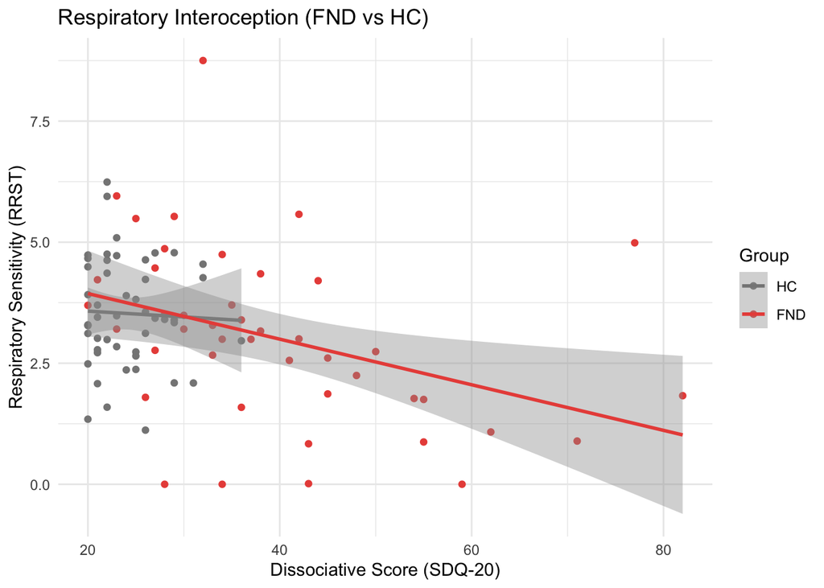

```r
# SDQ-RRST_sensitivity
RRST_sdq <- ggplot(df, aes(x = sdq, y = rrst_sensitivity, color = as.factor(group))) +
  geom_point() +  # Scatterplot for both groups
  geom_smooth(method = "lm", se = TRUE) +  # Add regression lines and SE
  labs(x = "Dissociative Score (SDQ-20)",
       y = "Respiratory Sensitivity (RRST)",
       title = "Respiratory Interoception (FND vs HC)",
       color = "Group") +  # Label for the legend
  theme_minimal() +
  scale_color_manual(values = c("1" = "#E95248", "0" = "#868686FF"),
                     labels = c("0" = "HC", "1" = "FND"))  # Custom labels
RRST_sdq
```

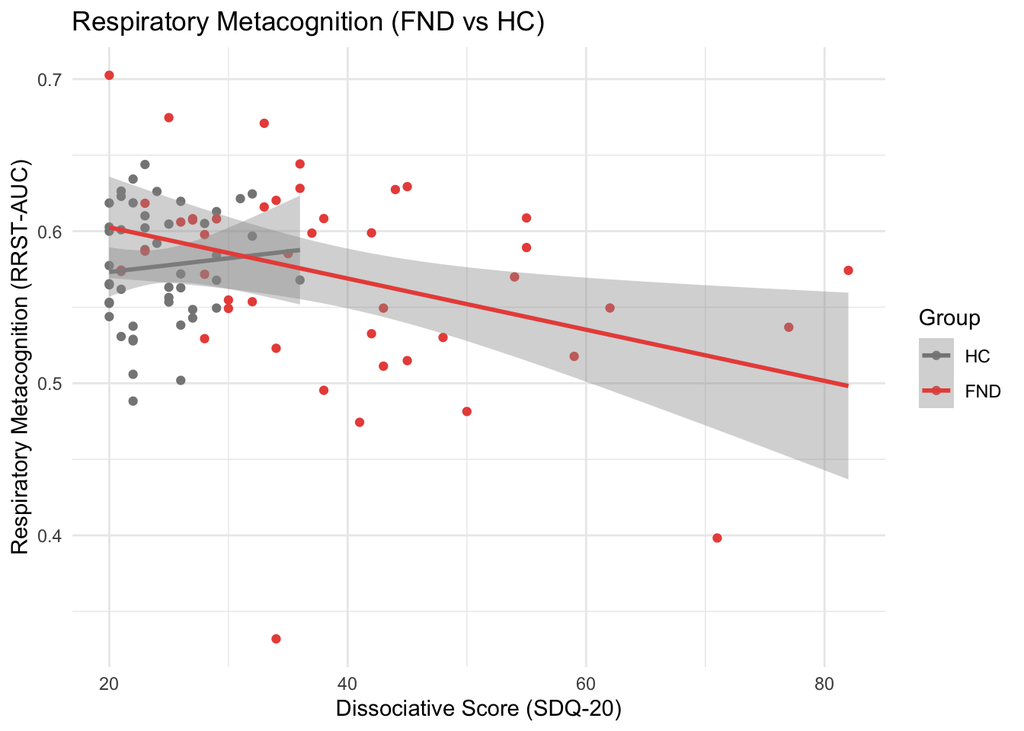

```r
# SDQ-metascore
RRST_meta_combined <- ggplot(df, aes(x = sdq, y = metascore, color = as.factor(group))) +
  geom_point() +  # Scatterplot for both groups
  geom_smooth(method = "lm", se = TRUE) +  # Add regression lines and SE
  labs(x = "Dissociative Score (SDQ-20)",
       y = "Respiratory Metacognition (RRST-AUC)",
       title = "Respiratory Metacognition (FND vs HC)",
       color = "Group") +  # Label for the legend
  theme_minimal() +
  scale_color_manual(values = c("1" = "#E95248", "0" = "#868686FF"),
                     labels = c("0" = "HC", "1" = "FND"))  # Custom labels
RRST_meta_combined
```

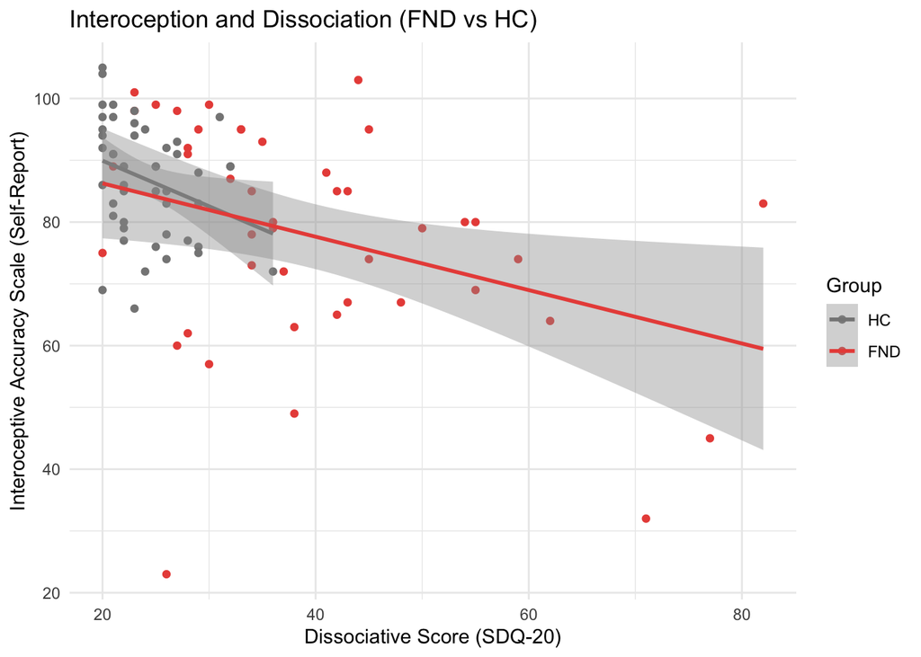

```r
# SDQ-IAS
IAS_sdq <- ggplot(df, aes(x = sdq, y = ias, color = as.factor(group))) +
  geom_point() +  # Scatterplot for both groups
  geom_smooth(method = "lm", se = TRUE) +  # Add regression lines and SE
  labs(x = "Dissociative Score (SDQ-20)",
       y = "Interoceptive Accuracy Scale (Self-Report)",
       title = "Interoception and Dissociation (FND vs HC)",
       color = "Group") +  # Label for the legend
  theme_minimal() +
  scale_color_manual(values = c("1" = "#E95248", "0" = "#868686FF"),
                     labels = c("0" = "HC", "1" = "FND"))  # Custom labels
IAS_sdq
```

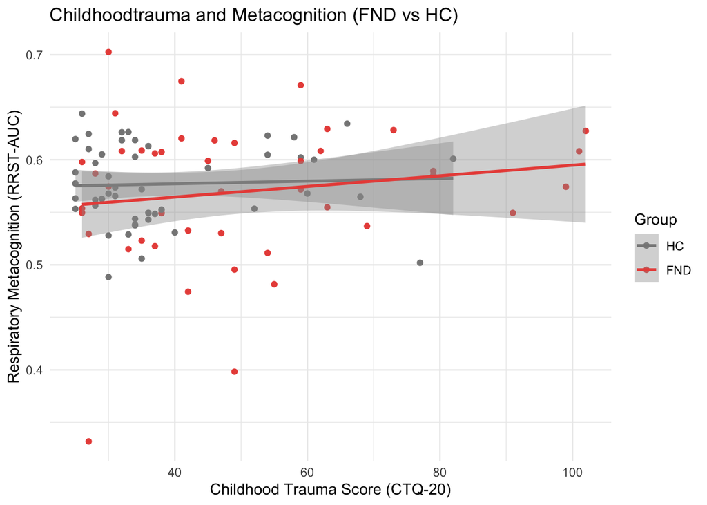

```r
# CTQ-metascore
CTQ_meta<- ggplot(df, aes(x = ctq_total, y = metascore, color = as.factor(group))) +
  geom_point() +  # Scatterplot for both groups
  geom_smooth(method = "lm", se = TRUE) +  # Add regression lines and SE
  labs(x = "Childhood Trauma Score (CTQ-20)",
       y = "Respiratory Metacognition (RRST-AUC)",
       title = "Childhoodtrauma and Metacognition (FND vs HC)",
       color = "Group") +  # Label for the legend
  theme_minimal() +
  scale_color_manual(values = c("1" = "#E95248", "0" = "#868686FF"),
                     labels = c("0" = "HC", "1" = "FND"))  # Custom labels
CTQ_meta
```

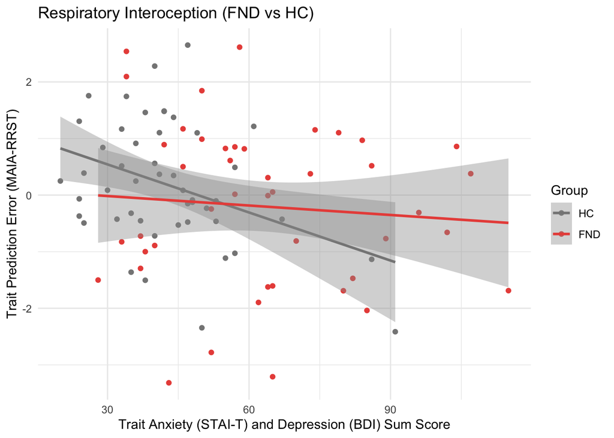

```r
# STAI-T-RRST_sensitivity
anxdepPE <- ggplot(df, aes(x = anx_dep_SUM, y = traitPE_maiaRRST, color = as.factor(group))) +
  geom_point() +  # Scatterplot for both groups
  geom_smooth(method = "lm", se = TRUE) +  # Add regression lines and SE
  labs(x = "Trait Anxiety (STAI-T) and Depression (BDI) Sum Score",
       y = "Trait Prediction Error (MAIA-RRST)",
       title = "Respiratory Interoception (FND vs HC)",
       color = "Group") +  # Label for the legend
  theme_minimal() +
  scale_color_manual(values = c("1" = "#E95248", "0" = "#868686FF"),
                     labels = c("0" = "HC", "1" = "FND"))  # Custom labels
anxdepPE
```

```r
#NOTE. 0 = perfect prediction: positive values indicate OVERestimation and negative values UNDERestimation
```

## 6) Overivew Results

Clinical Covariates: BMI, SEX, ANX-DEP-SUM, CTQ, SDQ  
Interoceptive Variables: RRST sensitivity, Metascore, MAIA, IAS, TraitPE of RRST using either MAIA or IAS

Higher SDQ was sig associated with group (p=0.000701), while lower IAS scores (t=-2.245, p=0.0273), lower RRST-sensitvity (t=-2-248, p=0.0271), and FND group (t=5.772, p=1.21e-07 ) was associated with higher SDQ scores.

Higher SDQ scores are associated with lower RRST sensitivity (t=-2.984, p=0.00374), when controlling for other clinical variables.

Higher scores in CTQ (t=2.150, p=0.0345), and lower SDQ (t=-2.929, p=0.0044) are associated with higher Metascores, when controlling for clinical variables.

Lower scores on ANX-DEP-SUM are associated with higher TraitPE using MAIA (t=-3.509 , p=0.000733), while no sig association has been detected with the TraitPE using IAS.

Separate Analysis per group:

HC only:

- ANX-DEP and BMI is associated with RRST sensitvitiy
- ANX-DEP and CTQ is associated with TraitPE-maia